# Prep TEROS data

PR

2024-03-19

### General purpose

I’m creating Rmds for each of the datastreams used in this project. TEROS data are relatively simple to ingest because they’re pulled from GDrive which is already formatted. However, because there are so many TEROS sensors, there’s a significant amount of quality control to document and justify.

### Initial plots

First, let’s look at the initial datasets, and see what kinds of issues we’ll need to address with our TEROS QC process:

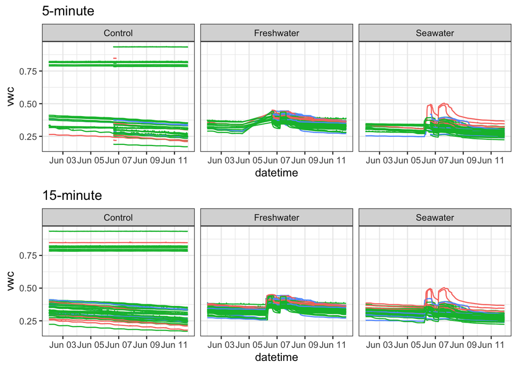

### QC

#### QC Step 1: remove sensors with only 15-cm resolution

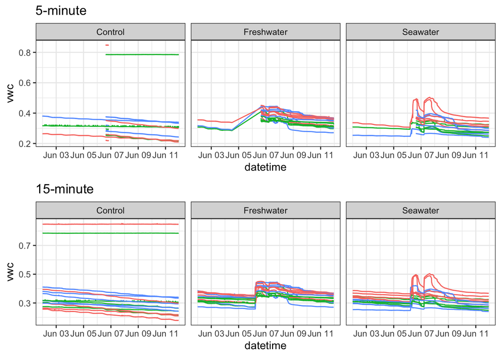

#### **DECISION #1:** It’s clear from this comparison that, unfortunately, the 5-minute datasets start right at the beginning of the event.

# —

#### QC Step 2: remove nonsense sensors

Based on QC Step 1 above, we’re going to be using the 15-minute datasets. Next up, there are two sensors in Control that don’t match any of the other sensors, and are reading unreasonably high VWC values. Let’s strip them out.

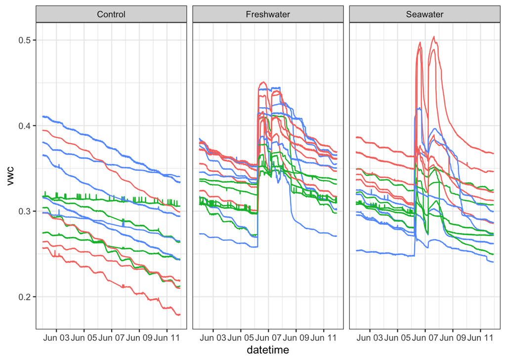

#### **DECISION #2:** Removed two sensors from Control based on VWC > 0.6

# —

#### QC Step 3: remove intermittent sensors

Next, we need to check if there are sensors that are missing a lot of data, which should not be gap-filled. We’ll do this simply by counting the number of records for a given period, and identifying if there are sensors with large gaps we can afford to lose:

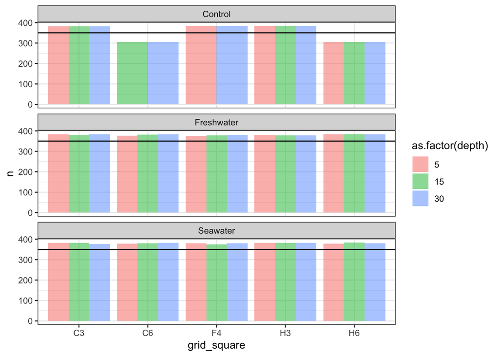

#### **DECISION #3:** Remove C6 and H6 from Control

# —

#### QC Step 4: gap-filling

```
## [1] "199 NAs present"
```

##### % of data missing by sensor

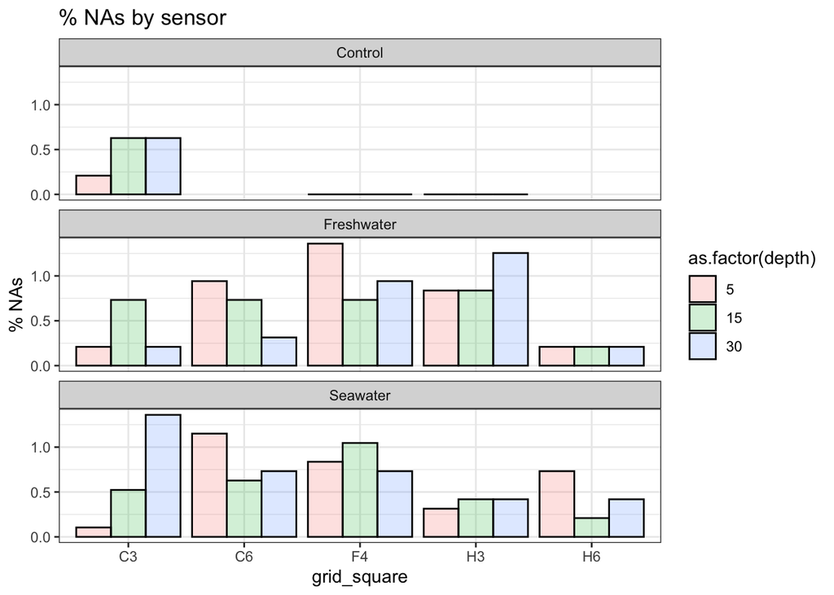

##### Length of gaps

Gap lengths are generally not very long, though a gap length >10 is equal to 2.5 hours, which is a little worrying

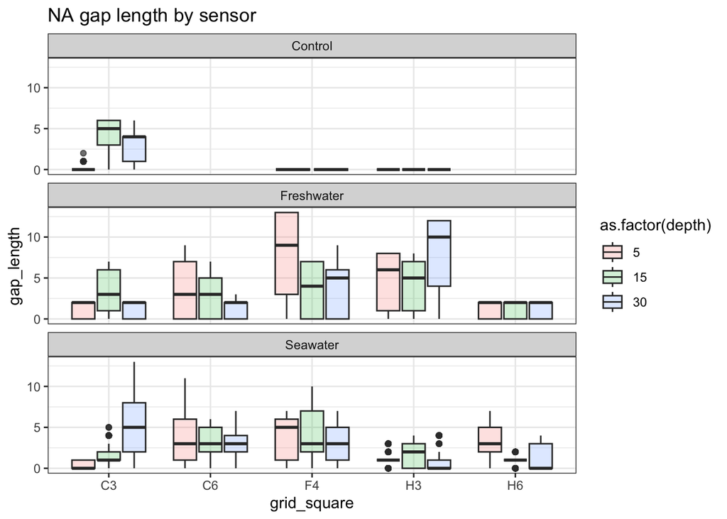

##### Location of gaps in time-series

Welp. It’s clear that there are some gaps during the event, so we’ll need to keep an eye on our gap-filling and see if it influences our dataset in any noticable or meaningful way. The good news is, we’ll be averaging between multiple sensors for each combination of depth and plot, so it is unlikely any given final value will be determined exclusively from gap-filled data.

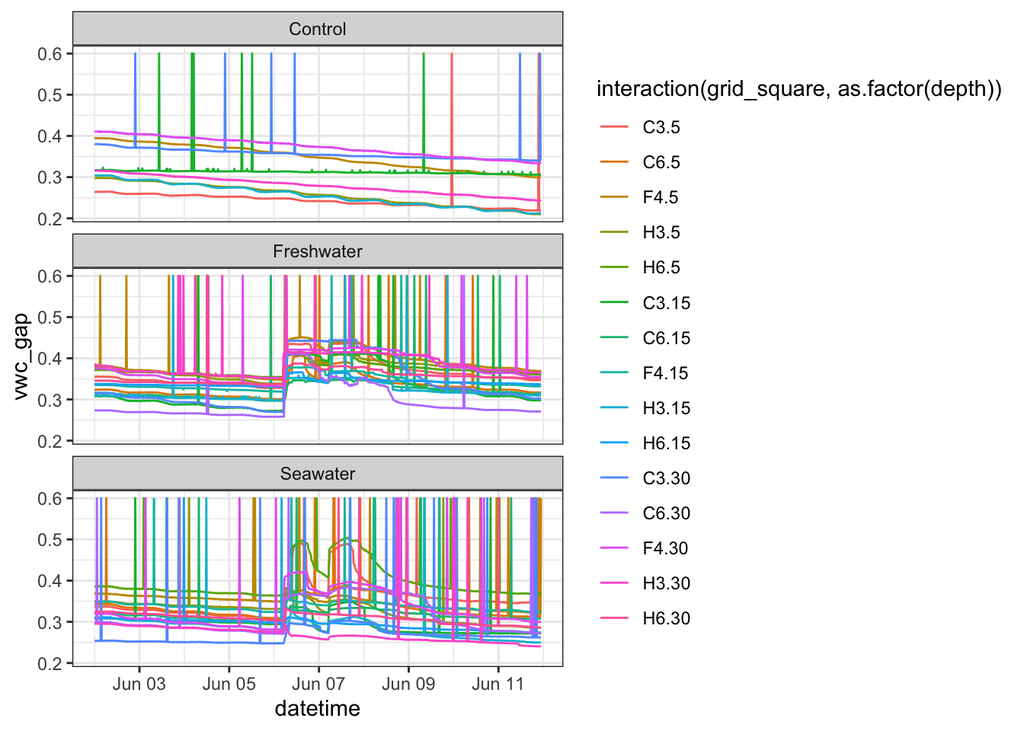

[figure not shown]

#### **DECISION #4:** Linearly gap-fill using the *zoo* package (199 missing values filled)

# —

#### QC Step 5: choose statistics to average depths across grid squares

As a final step, now that we’ve cleaned and gap-filled our data, we need to decide if we want to use the mean or median of sensors to calculate our final TEROS time-series. We’ll look at all three variables to make this decision (and check that we don’t need additional QC for them

##### Temperature

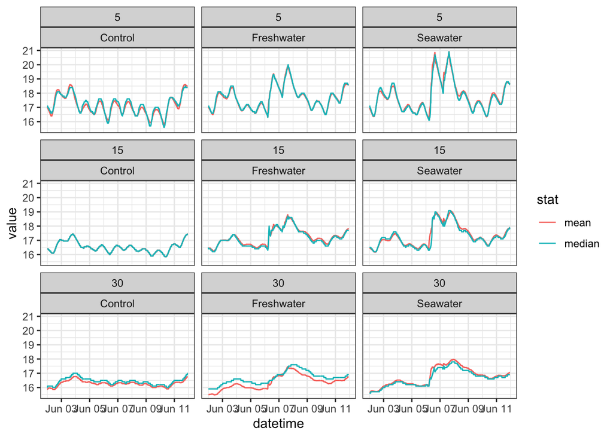

##### VWC

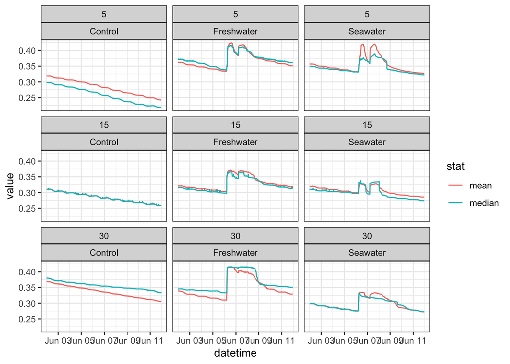

##### EC

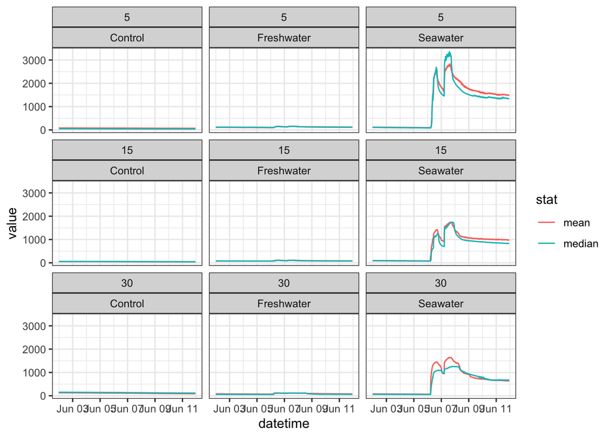

#### **DECISION #5:** Use means because it preserves the event signatures better

# —

#### Write out final dataset and make final plots

##### Temp

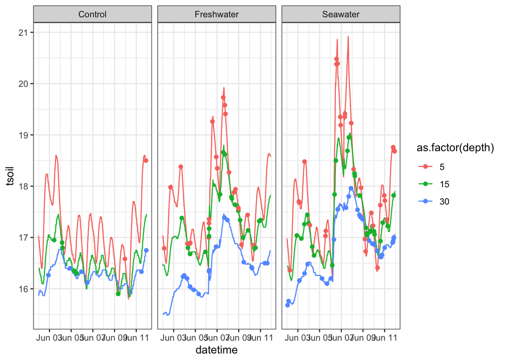

##### VWC

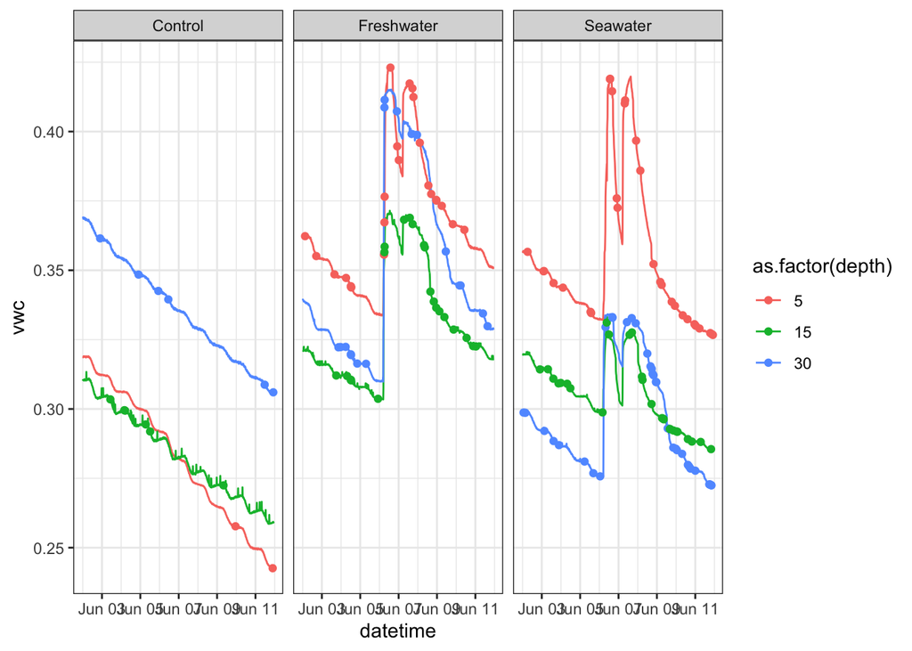

##### EC

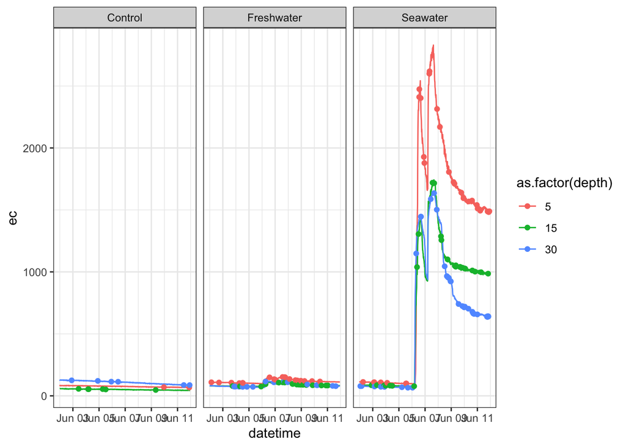